# Price Predication of Used Cars

Manish Gupta (manishg2@illinois.edu), Harshit Sinha (hksinha2@illinois.ed)

## Introduction

The price prediction for used cars is a very important part of used car business. Predicting prices accurately can help businesses and customers to settle deal at a fair price.

## Methods

```r
#reading data from the csv
library(readr)
train_data = read_csv("./train-data.csv")
test_data = read_csv("./test-data.csv")
```

#### Cleaning the dataset

The first thing we did was to clean the dataset that we are given. In the dataset, the values for `Power`, `Mileage` and `Engine` are added as strings with their units along with them. So we had to remove those units and convert their types to numeric.

Variables like `Location`,`Transmission`, `Fuel_Type` and `Owner_Type` can be considered as factor variables therefore they were changed to factor variables.

Columns for `X1` and `Name` were removed as they were not really affecting the price.

```r
#clean data function
clean_data = function(data) {
  #removing New  Price column
  data = data[,-13]
  remove_units = function(values) {
    remove_units_value =  function(value) {
      as.numeric(sub("\\s+\\D+$", "", value))
    }
    unlist(lapply(values, remove_units_value))
  }
  data$Location = factor(data$Location)
  data$Transmission = factor(data$Transmission)
  data$Fuel_Type = factor(data$Fuel_Type)
  data$Owner_Type = factor(data$Owner_Type)
  data$Power = remove_units(data$Power)
  data$Mileage = remove_units(data$Mileage)
  data$Engine = remove_units(data$Engine)
  data = na.omit(data)
  data = data[-which(data$Mileage == 0),]
  data = data[,-c(1,2)]
  return(data)
}

train_data = clean_data(train_data)
test_data = clean_data(test_data)
```

#### Splitting the dataset

We split our `train_data` into `trn_data` and `tst_data`. The `test_data` provided in the file with the dataset is for competition and does not include any `Price` paramter

```r
smp_size = floor(0.75 * nrow(train_data))

## set the seed to make your partition reproducible
set.seed(42)
train_ind = sample(seq_len(nrow(train_data)), size = smp_size)

trn_data = train_data[train_ind, ]
tst_data = train_data[-train_ind, ]

head(trn_data)
```

```
## # A tibble: 6 x 11
##   Location  Year Kilometers_Driv… Fuel_Type Transmission Owner_Type Mileage
##   <fct>    <dbl>            <dbl> <fct>     <fct>        <fct>        <dbl>
## 1 Coimbat…  2017            24806 Petrol    Manual       First         18.2
## 2 Coimbat…  2016            44340 Diesel    Automatic    First         17.0
## 3 Delhi     2012            68038 Diesel    Manual       First         20.1
## 4 Delhi     2016            22000 Diesel    Manual       First         24.3
## 5 Ahmedab…  2011            76000 CNG       Manual       First         26.3
## 6 Mumbai    2015            29631 Petrol    Automatic    First         18.9
## # … with 4 more variables: Engine <dbl>, Power <dbl>, Seats <dbl>,
## #   Price <dbl>
```

#### Correlation between parameters

```r
cor(trn_data[c("Kilometers_Driven","Mileage","Engine","Power")])
```

```
##                   Kilometers_Driven     Mileage      Engine       Power
## Kilometers_Driven        1.00000000 -0.05500041  0.08971581  0.04084805
## Mileage                 -0.05500041  1.00000000 -0.64849776 -0.56117361
## Engine                   0.08971581 -0.64849776  1.00000000  0.87573788
## Power                    0.04084805 -0.56117361  0.87573788  1.00000000
```

We can see from the correlation matrix that Power and Engine are very much correlated. Also Engine and Mileage also upto some extent. We will have to be careful before using all of them for our model.

#### Plotting relationships between the Price and other paramters

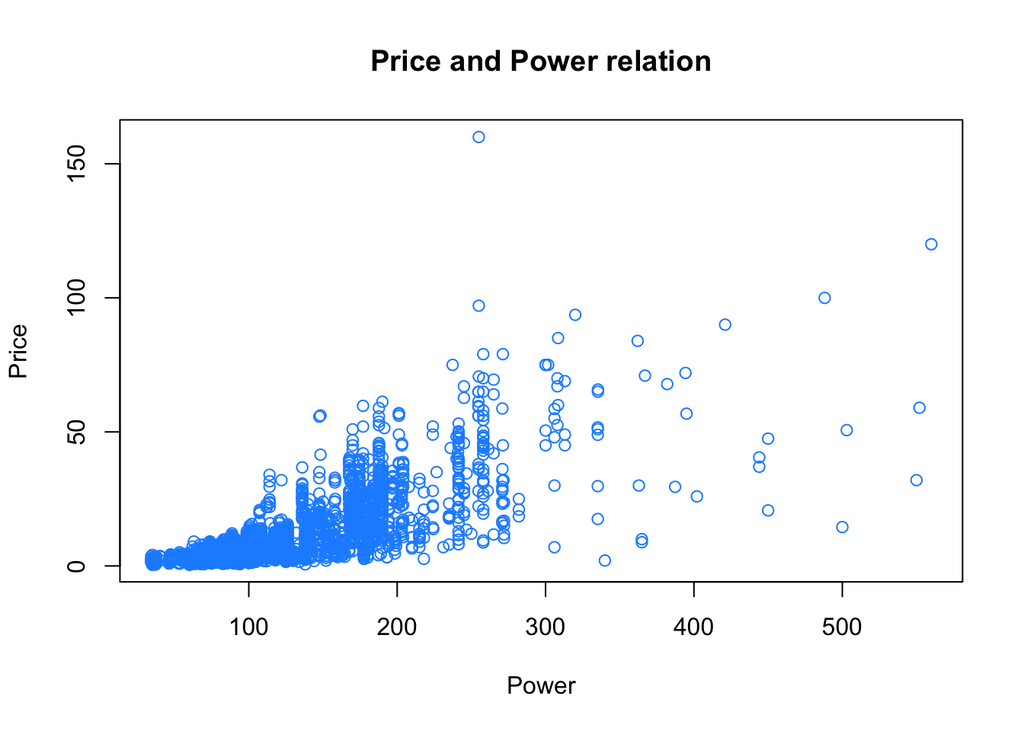

```r
plot(Price ~ Power, data = trn_data,
     col = "dodgerblue",
     main = "Price and Power relation")
```

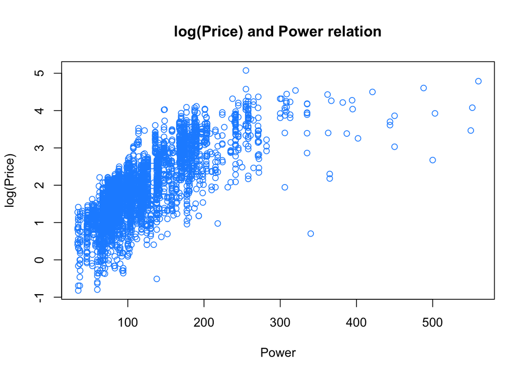

```r
plot(log(Price) ~ Power, data = trn_data,
     col = "dodgerblue",
     main = "log(Price) and Power relation")
```

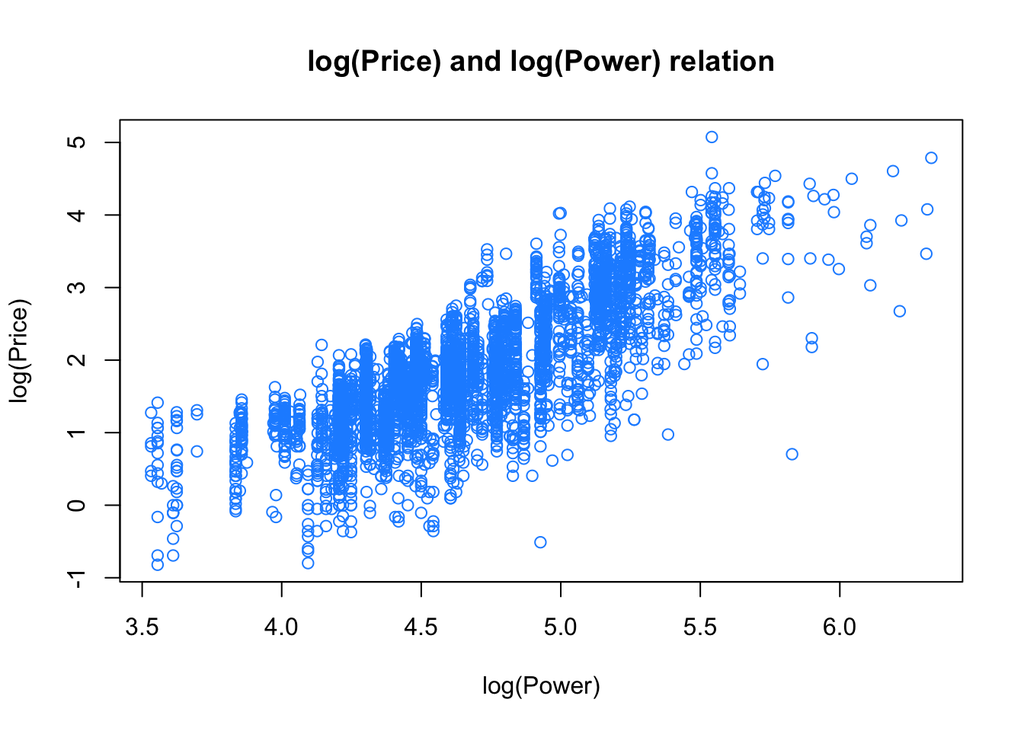

```r
plot(log(Price) ~ log(Power), data = trn_data,
     col = "dodgerblue",
     main = "log(Price) and log(Power) relation")
```

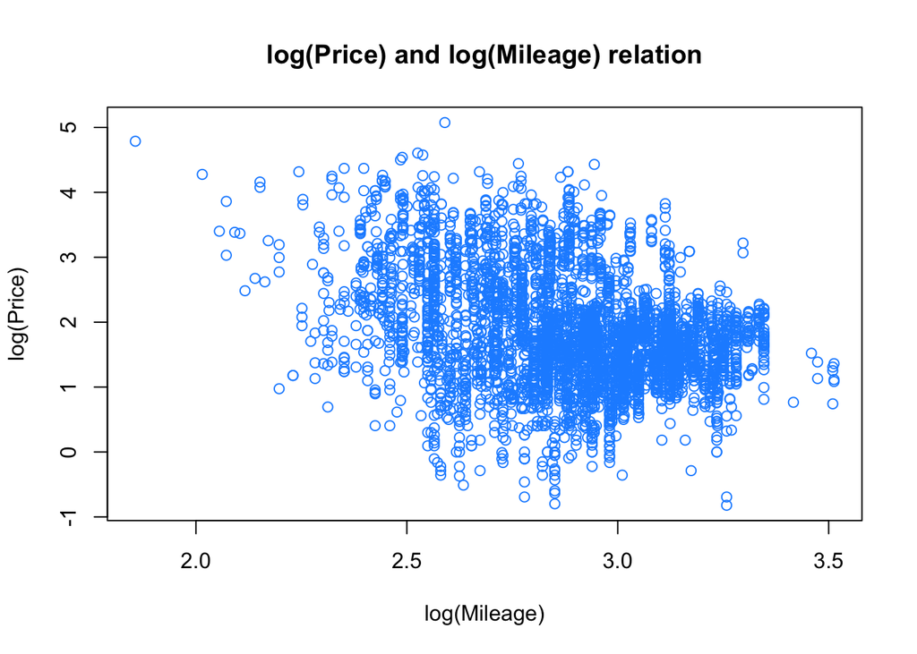

```r
plot(log(Price) ~ log(Mileage), data = trn_data, col = "dodgerblue",
     main = "log(Price) and log(Mileage) relation")
```

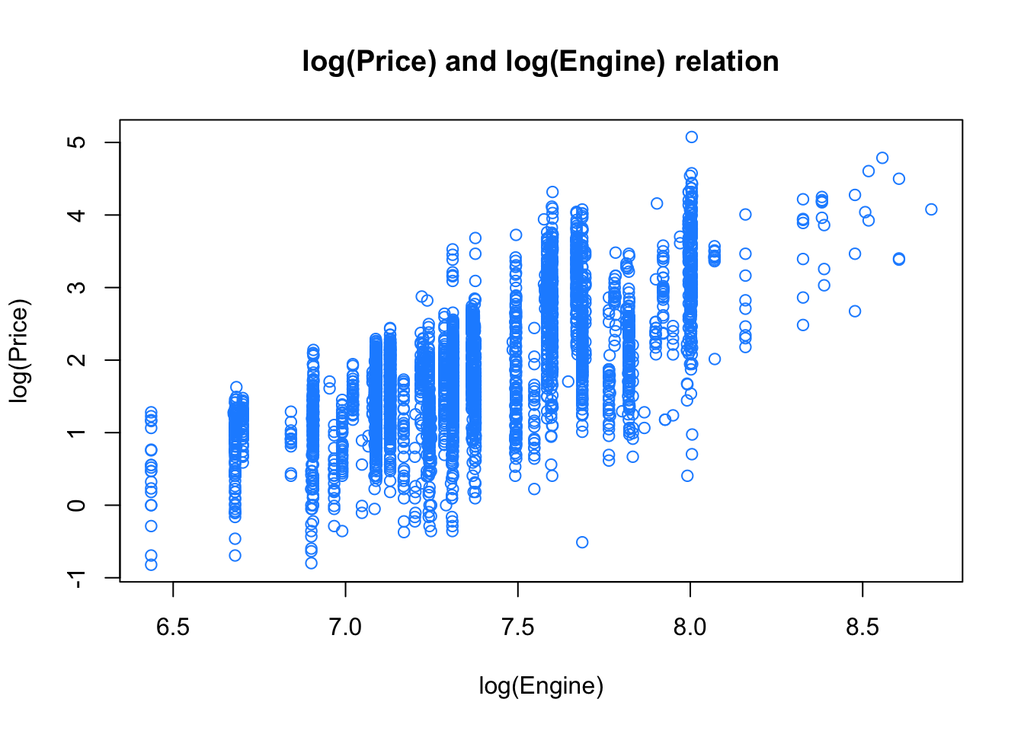

```r
plot(log(Price) ~ log(Engine), data = trn_data, col = "dodgerblue",
     main = "log(Price) and log(Engine) relation")
```

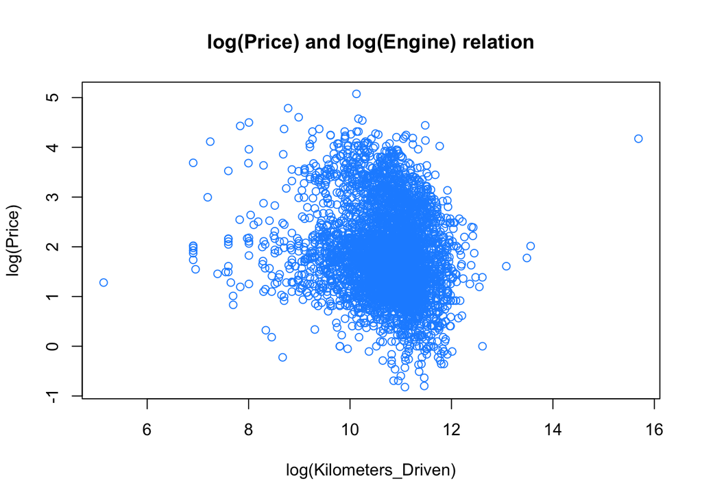

```r
plot(log(Price) ~ log(Kilometers_Driven), data = trn_data, col = "dodgerblue",
     main = "log(Price) and log(Engine) relation")
```

From these plots we were inferred that the logs of the above parameters are better suited for regression.

#### Functions to check Assumptions

```r
plot_fit_res = function(model) {
  plot(fitted(model), resid(model), col = "grey", pch = 20,
  xlab = "Fitted", ylab = "Residuals", main = "Data from Model 1")
  abline(h = 0, col = "darkorange", lwd = 2)
}
plot_qq = function(model) {
  qqnorm(resid(model), main = "Normal Q-Q Plot", col = "darkgrey")
  qqline(resid(model), col = "dodgerblue", lwd = 2)
}
plot_fit_pred = function(model, data) {
  predicted = predict(model, newdata = data)
  plot(predicted, log(data$Price), col = "grey", pch = 20,
  xlab = "Predicted", ylab = "Actual", main = "Data from Model 1")
  abline(a = 0, b = 1, col = "orange", lwd = 3)
}
```

#### Functions to compare different models

```r
calc_aic = function(model) {
  rss = sum(resid(model)^2)
  n = length(resid(model))
  p = length(model$coefficients)
  return(n*log(rss/n)+2*p)
}
calc_bic = function(model) {
  rss = sum(resid(model)^2)
  n = length(resid(model))
  p = length(model$coefficients)
  return(n*log(rss/n)+(log(n)*p))
}
calc_loocv_rmse = function(model) {
  return(sqrt(mean((resid(model) / (1 - hatvalues(model))) ^ 2)))
}
calc_adj_r2 = function(model) {
  mod_sum = summary(model)
  return(mod_sum[["adj.r.squared"]])
}
calc_quality_criterions = function(model) {
  return(data.frame("AIC" = calc_aic(model),
                    "BIC" = calc_bic(model),
                    "LOOCV_RMSE" = calc_loocv_rmse(model),
                    "ADJ_R_SQ" = calc_adj_r2(model)
                    ))
}
```

#### Creating and testing different models

The first model we created was an additive model usig all the parameters.

```r
model1 = lm(Price ~ ., data = trn_data)
calc_quality_criterions(model1)
```

```
##     AIC      BIC LOOCV_RMSE  ADJ_R_SQ
## 1 15951 16104.25   7.088395 0.7023269
```

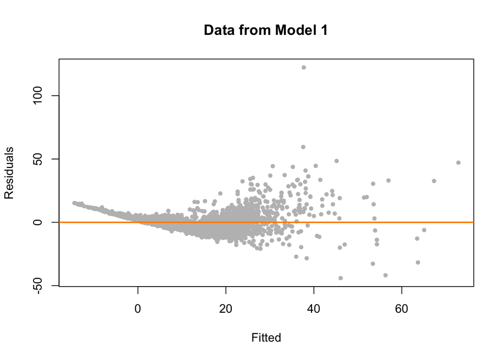

```r
plot_fit_res(model1)
```

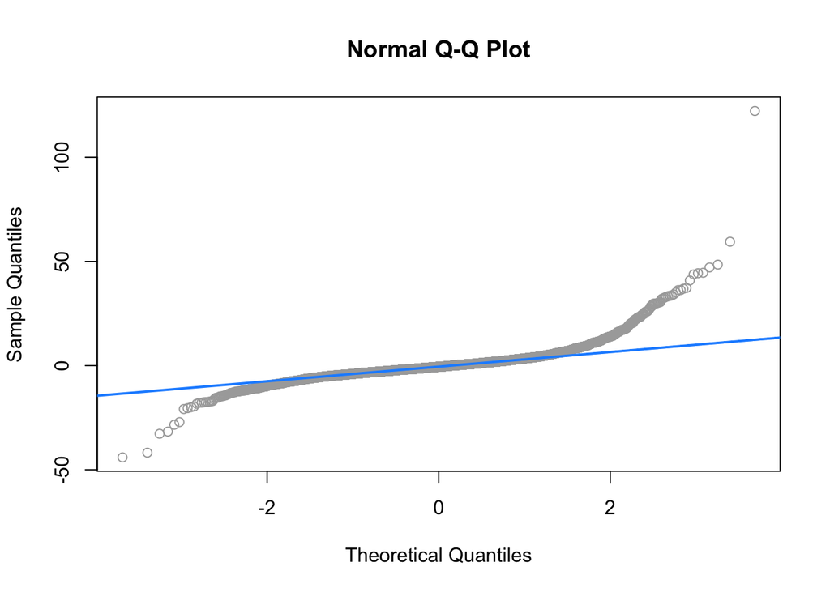

```r
plot_qq(model1)
```

As we have already seen from the plots that it is better to use the log for numeric parameters we also created the model using the logs for Power, Mileage and Engine.

```r
model2 = lm(log(Price) ~ Location+Year+log(Kilometers_Driven)+Fuel_Type+Transmission+Owner_Type+log(Mileage)+log(Engine)+log(Power)+Seats, data = trn_data)
calc_quality_criterions(model2)
```

```
##         AIC       BIC LOOCV_RMSE  ADJ_R_SQ
## 1 -10990.32 -10837.07  0.2858198 0.8895492
```

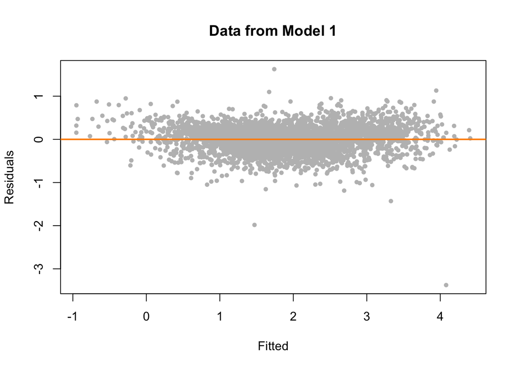

```r
plot_fit_res(model2)
```

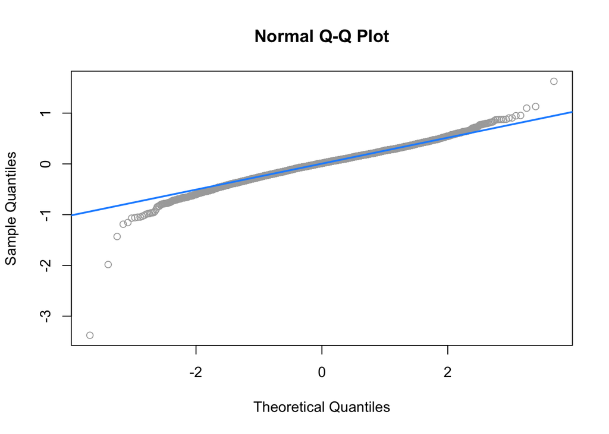

```r
plot_qq(model2)
```

We were able to improve all the criterias by just using log. AIC, BIC and LOOCV_RMSE decreased and ADJ_R_SQ increased.

We tried to further decrease the AIC and BIC by using the Backward search on the model2.

```r
model3 = step(model2, direction = "backward")
```

```
## Start:  AIC=-10990.32
## log(Price) ~ Location + Year + log(Kilometers_Driven) + Fuel_Type +
##     Transmission + Owner_Type + log(Mileage) + log(Engine) +
##     log(Power) + Seats
##
##                          Df Sum of Sq    RSS      AIC
## - Seats                   1     0.066 353.27 -10991.5
## <none>                                353.20 -10990.3
## - log(Engine)             1     1.331 354.54 -10975.8
## - log(Mileage)            1     2.673 355.88 -10959.3
## - Owner_Type              3     4.607 357.81 -10939.5
## - log(Kilometers_Driven)  1    12.203 365.41 -10843.5
## - Fuel_Type               3    32.572 385.78 -10609.7
## - Transmission            1    39.314 392.52 -10529.8
## - Location               10    52.305 405.51 -10405.0
## - log(Power)              1   113.459 466.66  -9771.4
## - Year                    1   237.892 591.10  -8735.4
##
## Step:  AIC=-10991.5
## log(Price) ~ Location + Year + log(Kilometers_Driven) + Fuel_Type +
##     Transmission + Owner_Type + log(Mileage) + log(Engine) +
##     log(Power)
##
##                          Df Sum of Sq    RSS      AIC
## <none>                                353.27 -10991.5
## - log(Engine)             1     1.268 354.54 -10977.8
## - log(Mileage)            1     2.680 355.95 -10960.4
## - Owner_Type              3     4.607 357.88 -10940.7
## - log(Kilometers_Driven)  1    12.537 365.81 -10840.7
## - Fuel_Type               3    33.162 386.43 -10604.3
## - Transmission            1    41.473 394.74 -10507.0
## - Location               10    52.407 405.68 -10405.2
## - log(Power)              1   129.739 483.01  -9622.5
## - Year                    1   251.587 604.86  -8636.5
```

```r
n = length(resid(model2))
model4 = step(model2, direction = "backward", k = log(n))
```

```
## Start:  AIC=-10837.07
## log(Price) ~ Location + Year + log(Kilometers_Driven) + Fuel_Type +
##     Transmission + Owner_Type + log(Mileage) + log(Engine) +
##     log(Power) + Seats
##
##                          Df Sum of Sq    RSS      AIC
## - Seats                   1     0.066 353.27 -10844.6
## <none>                                353.20 -10837.1
## - log(Engine)             1     1.331 354.54 -10829.0
## - log(Mileage)            1     2.673 355.88 -10812.4
## - Owner_Type              3     4.607 357.81 -10805.4
## - log(Kilometers_Driven)  1    12.203 365.41 -10696.6
## - Fuel_Type               3    32.572 385.78 -10475.6
## - Transmission            1    39.314 392.52 -10382.9
## - Location               10    52.305 405.51 -10315.6
## - log(Power)              1   113.459 466.66  -9624.5
## - Year                    1   237.892 591.10  -8588.5
##
## Step:  AIC=-10844.64
## log(Price) ~ Location + Year + log(Kilometers_Driven) + Fuel_Type +
##     Transmission + Owner_Type + log(Mileage) + log(Engine) +
##     log(Power)
##
##                          Df Sum of Sq    RSS    AIC
## <none>                                353.27 -10845
## - log(Engine)             1     1.268 354.54 -10837
## - log(Mileage)            1     2.680 355.95 -10820
## - Owner_Type              3     4.607 357.88 -10813
## - log(Kilometers_Driven)  1    12.537 365.81 -10700
## - Fuel_Type               3    33.162 386.43 -10476
## - Transmission            1    41.473 394.74 -10366
## - Location               10    52.407 405.68 -10322
## - log(Power)              1   129.739 483.01  -9482
## - Year                    1   251.587 604.86  -8496
```

```r
calc_quality_criterions(model4)
```

```
##        AIC       BIC LOOCV_RMSE  ADJ_R_SQ
## 1 -10991.5 -10844.64   0.285739 0.8895538
```

From the correlation testng earlier we had found that Engine and Power are highly corrlated. This means we should also try by removing the Engine Parameter and see if it improves anything.

```r
model5 = lm(log(Price) ~ Location+Year+log(Kilometers_Driven)+Fuel_Type+Transmission+Owner_Type+log(Mileage)+log(Power)+Seats, data = trn_data)
model5 = step(model5, direction = "backward", k = log(n))
```

```
## Start:  AIC=-10828.98
## log(Price) ~ Location + Year + log(Kilometers_Driven) + Fuel_Type +
##     Transmission + Owner_Type + log(Mileage) + log(Power) + Seats
##
##                          Df Sum of Sq    RSS      AIC
## - Seats                   1      0.00 354.54 -10837.3
## <none>                                354.54 -10829.0
## - Owner_Type              3      4.56 359.10 -10798.1
## - log(Mileage)            1      6.34 360.88 -10759.7
## - log(Kilometers_Driven)  1     12.09 366.63 -10690.3
## - Transmission            1     38.38 392.91 -10386.9
## - Location               10     52.14 406.67 -10311.5
## - Fuel_Type               3     56.52 411.06 -10205.8
## - Year                    1    236.60 591.14  -8596.6
## - log(Power)              1    343.14 697.68  -7870.3
##
## Step:  AIC=-10837.32
## log(Price) ~ Location + Year + log(Kilometers_Driven) + Fuel_Type +
##     Transmission + Owner_Type + log(Mileage) + log(Power)
##
##                          Df Sum of Sq    RSS      AIC
## <none>                                354.54 -10837.3
## - Owner_Type              3      4.56 359.10 -10806.5
## - log(Mileage)            1      9.04 363.58 -10735.3
## - log(Kilometers_Driven)  1     12.21 366.75 -10697.3
## - Transmission            1     40.25 394.79 -10374.4
## - Location               10     52.15 406.69 -10319.7
## - Fuel_Type               3     68.24 422.77 -10091.0
## - Year                    1    251.81 606.35  -8493.6
## - log(Power)              1    357.65 712.19  -7788.5
```

```r
calc_quality_criterions(model5)
```

```
##        AIC       BIC LOOCV_RMSE  ADJ_R_SQ
## 1 -10977.8 -10837.32   0.286194 0.8891829
```

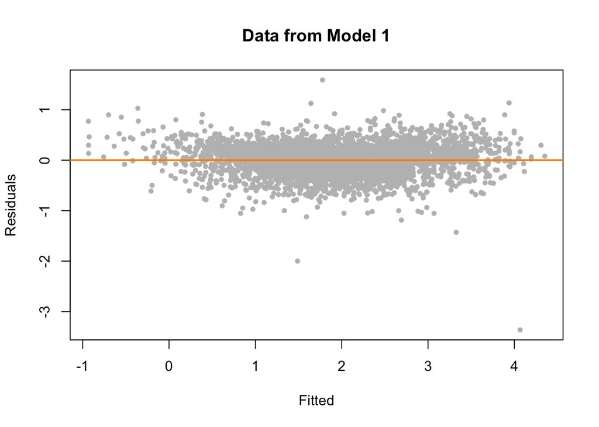

```r
plot_fit_res(model5)
```

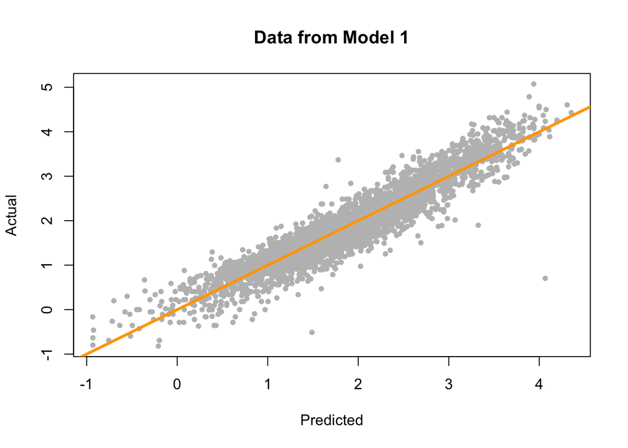

```r
plot_fit_pred(model5, trn_data)
```

We then also tried some interaction models

```r
model6 = lm(log(Price) ~ (Location+Year+log(Kilometers_Driven)+Fuel_Type+Transmission+Owner_Type+log(Mileage)+log(Engine)+log(Power)+Seats)^2, data = trn_data)
model7 = step(model6, direction = "backward", trace = FALSE)
calc_quality_criterions(model7)
```

```
##        AIC       BIC LOOCV_RMSE  ADJ_R_SQ
## 1 -11908.8 -11346.88        Inf 0.9117736
```

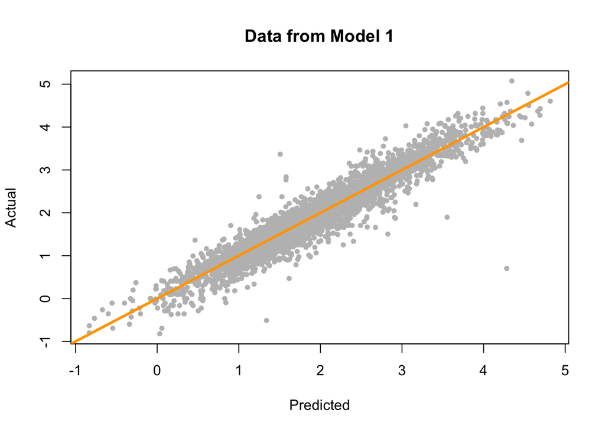

```r
plot_fit_pred(model7, trn_data)
```

Using model7 we were further able to decrease the AIC and BIC from the additive models, but the LOOCV_RMSE is coming Inf which appears to be a problem.